# Exploratory Data Analysis

## We're exploring data set contains 113,937 loans with 81 variables or features on each loan, including loan amount, borrower rate (or interest rate), current loan status, borrower income, and many others.

### Some of the questions we want to find out their answers

### What factors affect a loan’s outcome status?

### What affects the borrower’s APR or interest rate?

### What's the relation relation between Credit Lines, Income Range and Employment Status?

### What's the most probable city of borrowers ?

### What's IncomeRange Percantage between variety of loaners?

### relation bbetween loan status and original amount of loan

## Importing Dataset and Required Packages

```python
import pandas as pd
import seaborn as sns

loans_df = pd.read_csv ('prosperLoanData.csv')
loans_df.head()
```

|  | ListingKey | ListingNumber | ListingCreationDate | CreditGrade | Term | LoanStatus | ClosedDate | BorrowerAPR | BorrowerRate | LenderYield | ... | LP_ServiceFees | LP_CollectionFees | LP_GrossPrincipalLoss | LP_NetPrincipalLoss | LP_NonPrincipalRecoverypayments | PercentFunded | Recommendations | InvestmentFromFriendsCount | InvestmentFromFriendsAmount | Investors |
| --- | --- | --- | --- | --- | --- | --- | --- | --- | --- | --- | --- | --- | --- | --- | --- | --- | --- | --- | --- | --- | --- |
| 0 | 1021339766868145413AB3B | 193129 | 2007-08-26 19:09:29.263000000 | C | 36 | Completed | 2009-08-14 00:00:00 | 0.16516 | 0.1580 | 0.1380 | ... | -133.18 | 0.0 | 0.0 | 0.0 | 0.0 | 1.0 | 0 | 0 | 0.0 | 258 |
| 1 | 10273602499503308B223C1 | 1209647 | 2014-02-27 08:28:07.900000000 | NaN | 36 | Current | NaN | 0.12016 | 0.0920 | 0.0820 | ... | 0.00 | 0.0 | 0.0 | 0.0 | 0.0 | 1.0 | 0 | 0 | 0.0 | 1 |
| 2 | 0EE9337825851032864889A | 81716 | 2007-01-05 15:00:47.090000000 | HR | 36 | Completed | 2009-12-17 00:00:00 | 0.28269 | 0.2750 | 0.2400 | ... | -24.20 | 0.0 | 0.0 | 0.0 | 0.0 | 1.0 | 0 | 0 | 0.0 | 41 |
| 3 | 0EF5356002482715299901A | 658116 | 2012-10-22 11:02:35.010000000 | NaN | 36 | Current | NaN | 0.12528 | 0.0974 | 0.0874 | ... | -108.01 | 0.0 | 0.0 | 0.0 | 0.0 | 1.0 | 0 | 0 | 0.0 | 158 |
| 4 | 0F023589499656230C5E3E2 | 909464 | 2013-09-14 18:38:39.097000000 | NaN | 36 | Current | NaN | 0.24614 | 0.2085 | 0.1985 | ... | -60.27 | 0.0 | 0.0 | 0.0 | 0.0 | 1.0 | 0 | 0 | 0.0 | 20 |

5 rows × 81 columns

## Univariate Plot

## Checking percentage of people who owns home

### As seen below that the percents are nearly equal so, there's no relationship between it and the loaning

```
[Text(0.5, 1.0, 'Homes Ownership')]
```

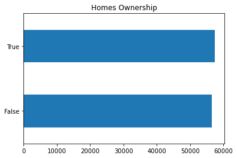

```python
loans_df['IsBorrowerHomeowner'].value_counts().sort_values().plot(kind = 'barh').set(title='Homes Ownership')
# get the count of home ownership or not and sort the highest value of home ownership
```

```python
loans_df.IsBorrowerHomeowner.value_counts(normalize=True)
#convert the value from previous cell to percentage through normalization
```

```
True     0.504472
False    0.495528
Name: IsBorrowerHomeowner, dtype: float64
```

## Checking Borrower's Annual Percentage Rate levels

```python
print(' Minimum Annual Percentage Rate is: ',loans_df['BorrowerAPR'].min())
print(' Maximum Annual Percentage Rate is: ',loans_df['BorrowerAPR'].max())
print(' Average Annual Percentage Rate is: ',loans_df['BorrowerAPR'].mean())
```

```
 Minimum Annual Percentage Rate is:  0.00653
 Maximum Annual Percentage Rate is:  0.51229
 Average Annual Percentage Rate is:  0.218827655909788
```

## Setting plot dimensions

```python
# set the size of plot
sns.set(rc={'figure.figsize':( 11.69, 8.27)})
```

## Checking Bivariate relation between no. of credit lines and estimated loss for the client

### Finding: at the low and high CurrentCreditLines there're people with low and high EstimatedLoss value so, there's no relationship

```
[Text(0.5, 1.0, 'No. of Credit Lines and Estimated Loss')]
```

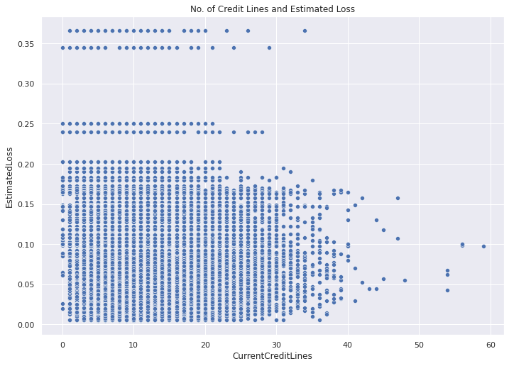

```python
# Bivariate relation by plotting 2 features on x and y axes and set the title
sns.scatterplot(data=loans_df, x="CurrentCreditLines", y="EstimatedLoss").set(title='No. of Credit Lines and Estimated Loss')
```

## Checking Bivariate relation between interest rate and annual percentage rate for the client

### Finding: There's a clear direct propotion between them

```
[Text(0.5, 1.0, 'Relation between Borrower Rate and annual percentage rate')]
```

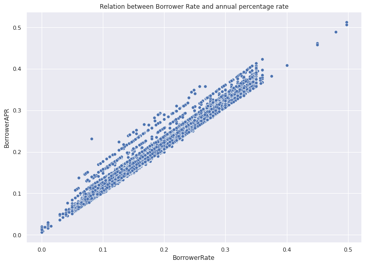

```python
# Another Bivariate relation by plotting 2 features on x and y axes and set the title
sns.scatterplot(data=loans_df, x="BorrowerRate", y="BorrowerAPR").set(title='Relation between Borrower Rate and annual percentage rate')
```

## Multivariant relation between Credit Lines, Income Range and Employment Status

### There is a dense amount of people of employed and fulltime categories in 5 variable income ranges

```
[Text(0.5, 1.0, 'Relation between Income Range, Credit Lines and Employment Status')]
```

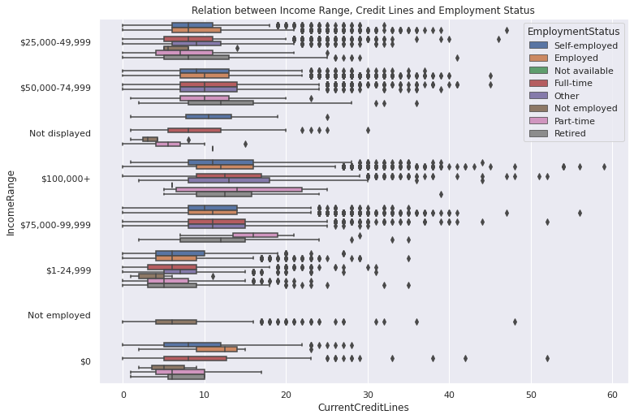

```python
# Multivariant relation by plotting 2 features on x, y axes and mark through 3rd variable and set the title
#sns.scatterplot(data=loans_df, x="CurrentCreditLines", y="IncomeRange", hue="EmploymentStatus").set(title='Relation between Income Range, Credit Lines and Employment Status')
sns.boxplot(x="CurrentCreditLines", y="IncomeRange", hue="EmploymentStatus",data=loans_df).set(title='Relation between Income Range, Credit Lines and Employment Status')
```

## Univariate Plot

### Finding: That might be give indications of costy life in the city or high life of investment in the city population

```
[Text(0.5, 1.0, 'Detecting most city of borrowers')]
```

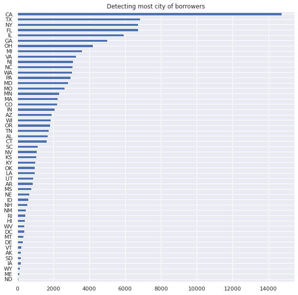

```python
# Change plot size to 10*10
# plot the highest borrowers in cities by kind bar chart
sns.set(rc={'figure.figsize':(10,10)})
loans_df['BorrowerState'].value_counts().sort_values().plot(kind = 'barh').set(title='Detecting most city of borrowers')
```

```python
# Get percentage of borrowers in cities
loans_df.BorrowerState.value_counts(normalize=True)
```

```
CA    0.135738
TX    0.063105
NY    0.062063
FL    0.061980
IL    0.054611
GA    0.046190
OH    0.038710
MI    0.033139
VA    0.030234
NJ    0.028564
NC    0.028444
WA    0.028112
PA    0.027411
MD    0.026019
MO    0.024119
MN    0.021379
MA    0.020678
CO    0.020383
IN    0.019166
AZ    0.017533
WI    0.016989
OR    0.016759
TN    0.016021
AL    0.015486
CT    0.015006
SC    0.010348
NV    0.010053
KS    0.009795
KY    0.009066
OK    0.008956
LA    0.008799
UT    0.008089
AR    0.007886
MS    0.007259
NE    0.006216
ID    0.005525
NH    0.005082
NM    0.004353
RI    0.004012
HI    0.003772
WV    0.003606
DC    0.003523
MT    0.003044
DE    0.002767
VT    0.001909
AK    0.001845
SD    0.001743
IA    0.001716
WY    0.001383
ME    0.000932
ND    0.000480
Name: BorrowerState, dtype: float64
```

## Univariate Chart

## Checking the categories of employment percentage

### Finding: Most of them are employed

```
[Text(0.5, 1.0, 'categories of employment percentage')]
```

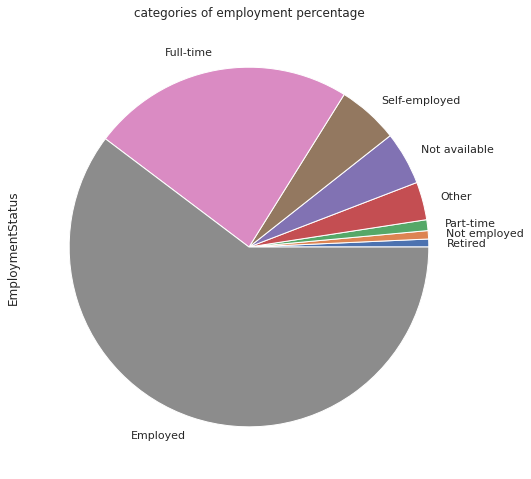

```python
import matplotlib.pyplot as plt
import numpy as np

# Change plot size to 11.69* 8.27
# plot the types of Employment Status by kind pie chart

sns.set(rc={'figure.figsize':( 11.69, 8.27)})
loans_df['EmploymentStatus'].value_counts().sort_values().plot(kind = 'pie').set(title='categories of employment percentage')
```

```python
# Get percentage of Employment Status
loans_df.EmploymentStatus.value_counts(normalize=True)
```

```
Employed         0.602801
Full-time        0.235983
Self-employed    0.054924
Not available    0.047877
Other            0.034079
Part-time        0.009742
Not employed     0.007477
Retired          0.007118
Name: EmploymentStatus, dtype: float64
```

## Univariate Chart

## Prosper Rating Percantage between variety of loaners

### Finding: C is the most rating appeared

```
[Text(0.5, 1.0, 'Prosper Rating Percantage between variety of loaners')]
```

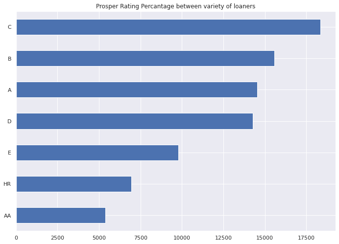

```python
# Prosper Rating counts between variety of loaners by kind bar chart
loans_df['ProsperRating (Alpha)'].value_counts().sort_values().plot(kind = 'barh').set(title='Prosper Rating Percantage between variety of loaners')
```

```python
# Get percentage of Prosper Rating among borrowers
loans_df['ProsperRating (Alpha)'].value_counts(normalize=True)
```

```
C     0.216197
B     0.183623
A     0.171485
D     0.168220
E     0.115435
HR    0.081730
AA    0.063309
Name: ProsperRating (Alpha), dtype: float64
```

## Univariate Chart

## IncomeRange Percantage between variety of loaners

### Finding: 25K - 50K is the most income appeared

```
[Text(0.5, 1.0, 'Income Range Percantage between variety of loaners')]
```

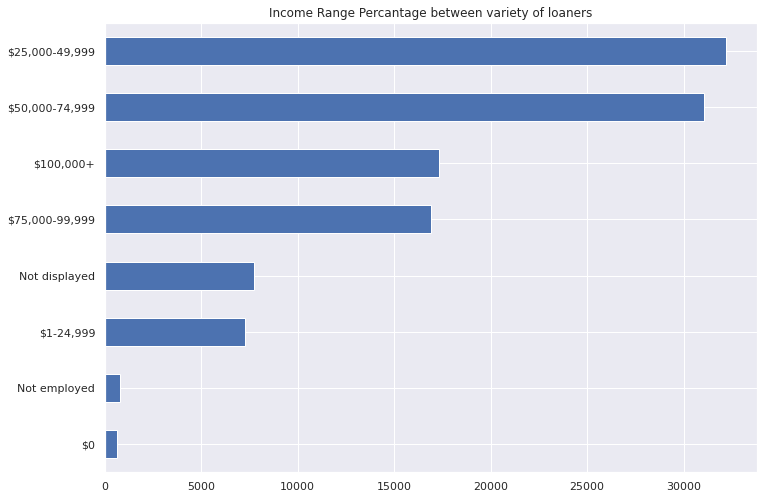

```python
# Income Range counts between variety of loaners by kind bar chart
loans_df['IncomeRange'].value_counts().sort_values().plot(kind = 'barh').set(title='Income Range Percantage between variety of loaners')
```

```python
# Income Range Percantage between variety of loaners
loans_df.IncomeRange.value_counts(normalize=True)
```

```
$25,000-49,999    0.282542
$50,000-74,999    0.272519
$100,000+         0.152163
$75,000-99,999    0.148468
Not displayed     0.067941
$1-24,999         0.063842
Not employed      0.007074
$0                0.005450
Name: IncomeRange, dtype: float64
```

## Bivariate Chart

## Trying to find a relation between income range and borrower rate

### Finding: There's no relationship

```
[Text(0.5, 1.0, 'Relation between income range and borrower rate')]
```

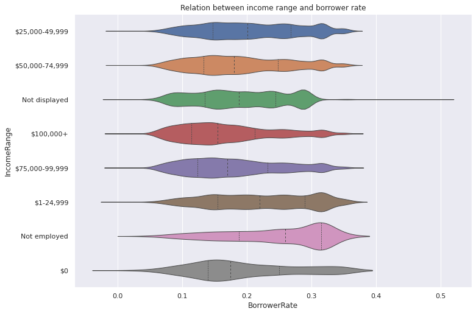

```python
# Bivariate relation by plotting 2 features of loans_df dataset on x and y axes and set the title
sns.violinplot(data=loans_df, x="BorrowerRate", y="IncomeRange",
               split=True, inner="quart", linewidth=1).set(title='Relation between income range and borrower rate')
```

## Bivariate Chart

## Trying to find a relation between income range and borrower state

### Finding: There's no relationship

```
[Text(0.5, 1.0, 'Relation between income range and borrower state')]
```

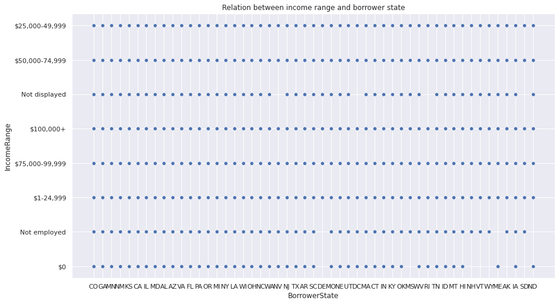

```python
# Change plot size to 14.70* 8.27
# Bivariate relation by plotting 2 features of loans_df dataset on x and y axes and set the title
sns.set(rc={'figure.figsize':( 14.70, 8.27)})
sns.scatterplot(data=loans_df, x="BorrowerState", y="IncomeRange").set(title='Relation between income range and borrower state')
```

## Bivariate Chart

## Trying to find a relation between income range and original amount of loan

### Finding: There's an increment betweeen the amount of loaners who have 100K income

```
[Text(0.5, 1.0, 'relation between income range and original amount of loan')]
```

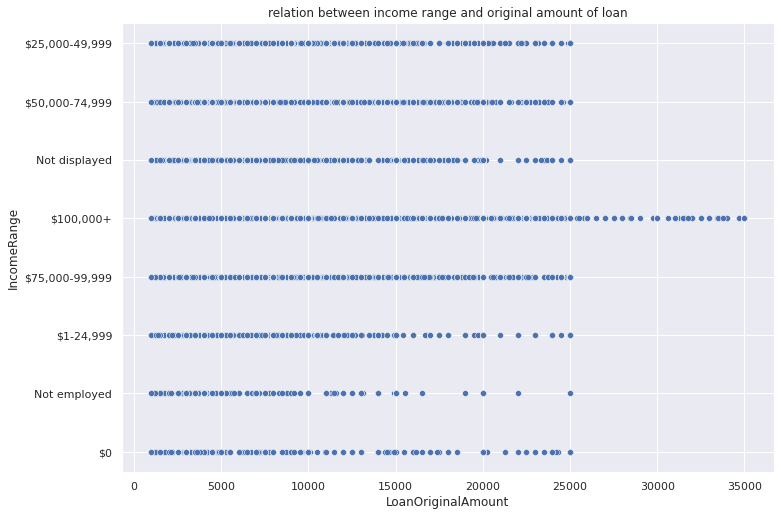

```python
# Change plot size to 11.69*8.27
# Bivariate relation by plotting 2 features of loans_df dataset on x and y axes and set the title
sns.set(rc={'figure.figsize':( 11.69, 8.27)})
sns.scatterplot(data=loans_df, x="LoanOriginalAmount", y="IncomeRange").set(title='relation between income range and original amount of loan')
```

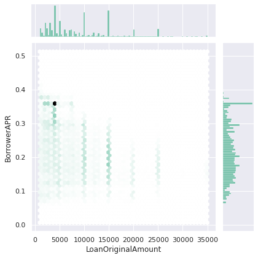

```python
sns.set(rc={'figure.figsize':( 11.69, 8.27)})
sns.jointplot(x=loans_df.LoanOriginalAmount, y=loans_df.BorrowerAPR, kind="hex", color="#4CB391")
```

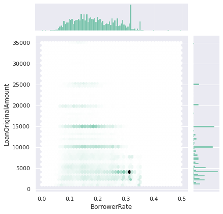

```python
sns.set(rc={'figure.figsize':( 11.69, 8.27)})
sns.jointplot(x=loans_df.BorrowerRate, y=loans_df.LoanOriginalAmount, kind="hex", color="#4CB391")
```

## Bivariate Chart

## Trying to find a relation between income range and Available Bankcard Credit

```
[Text(0.5, 1.0, 'Relation between income range and Available Bankcard Credit')]
```

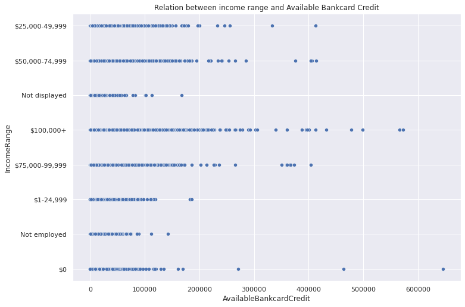

```python
# Bivariate relation by plotting 2 features of loans_df dataset on x and y axes and set the title
sns.scatterplot(data=loans_df, x="AvailableBankcardCredit", y="IncomeRange").set(title='Relation between income range and Available Bankcard Credit')
```

## Multivariant Chart

## Finding: As seen below that there's an indirect propotion between Prosper Rating and estimated loss

```
[Text(0.5, 1.0, 'Relation between original amount of loan, prosper rating and estimated loss')]
```

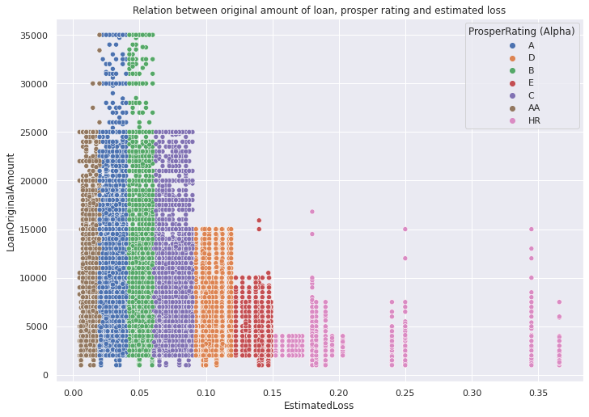

```python
# Multivariant relation by plotting 2 features of loans_df on x, y axes and mark through 3rd variable and set the title
sns.scatterplot(data=loans_df, x="EstimatedLoss", y="LoanOriginalAmount", hue="ProsperRating (Alpha)").set(title='Relation between original amount of loan, prosper rating and estimated loss')
```

## Multivariant Chart

### Finding: It's found that most of 100K income category own home and in 2 catgories( not employed and 0 to 25K) most of them don't own home

```
[Text(0.5, 1.0, 'Relation between income range, home ownership and credit lines')]
```

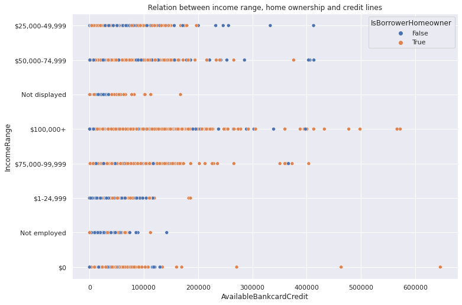

```python
# Multivariant relation by plotting 2 features of loans_df on x, y axes and mark through 3rd variable and set the title
sns.scatterplot(data=loans_df, x="AvailableBankcardCredit", y="IncomeRange", hue="IsBorrowerHomeowner").set(title='Relation between income range, home ownership and credit lines')
```

```
[Text(0.5, 1.0, 'Relation between estimated loss, Credit Lines and Employment Status')]
```

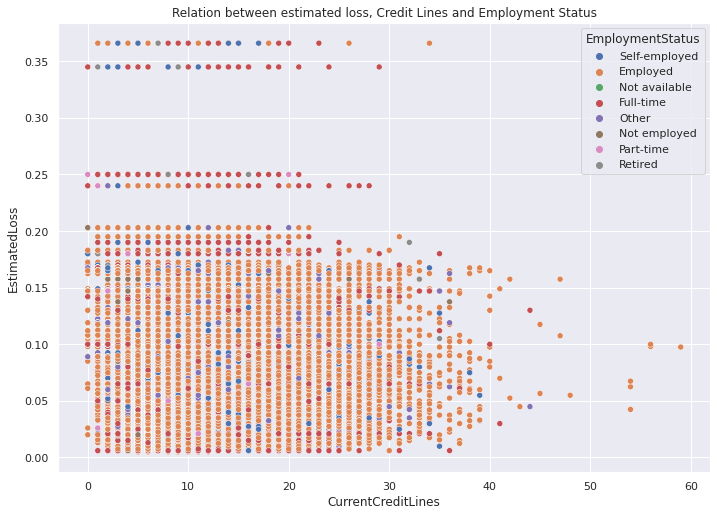

```python
# Multivariant relation by plotting 2 features of loans_df on x, y axes and mark through 3rd variable and set the title
sns.scatterplot(data=loans_df, x="CurrentCreditLines", y="EstimatedLoss", hue="EmploymentStatus").set(title='Relation between estimated loss, Credit Lines and Employment Status')
```

## Bivariate Chart

## Finding:As seen that very little amount of people cancelled and most of them in current state and have high loan originals amount

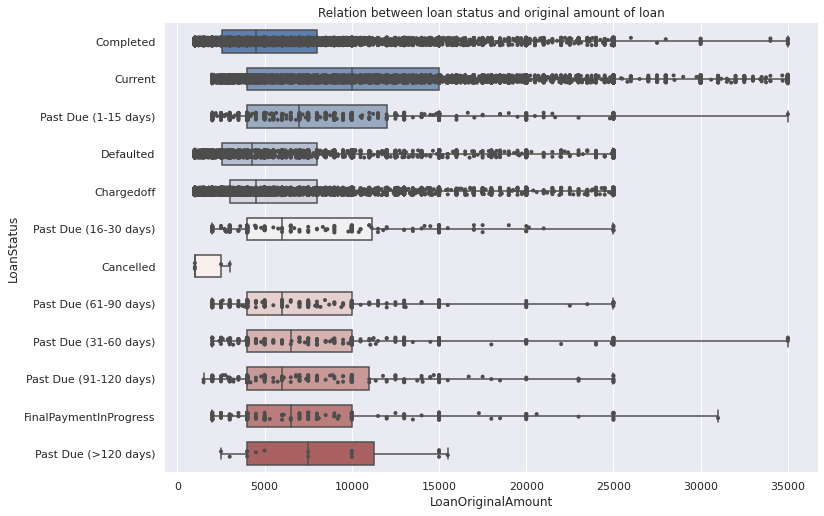

```python
# Bivariate relation by plotting 2 features of loans_df dataset on x and y axes and set the title
#sns.scatterplot(data=loans_df, x="LoanOriginalAmount", y="LoanStatus").set(title='Relation between loan status and original amount of loan')
sns.boxplot(x="LoanOriginalAmount", y="LoanStatus", data=loans_df,
            whis=[0, 100], width=.6, palette="vlag").set(title='Relation between loan status and original amount of loan')

sns.stripplot(x="LoanOriginalAmount", y="LoanStatus", data=loans_df,
              size=4, color=".3", linewidth=0)
sns.despine(trim=True, left=True)
```

## Univariate Chart

### Finding: As seen that highest percentage in current and completed states and how are about to finish in rest of categories are very low

```
[Text(0.5, 1.0, 'categories of loan status percentage')]
```

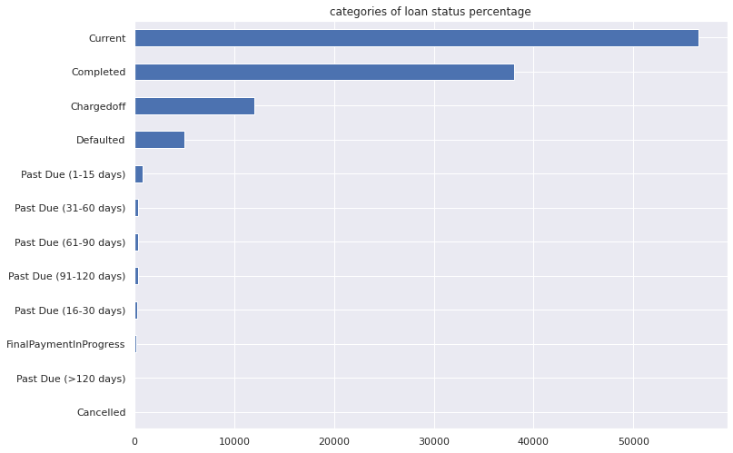

```python
# Change plot size to 11.69* 8.27
# plot the types of Loan Status by kind bar chart
sns.set(rc={'figure.figsize':( 11.69, 8.27)})
loans_df['LoanStatus'].value_counts().sort_values().plot(kind = 'barh').set(title='categories of loan status percentage')
```

## Bivariate Chart

```
[Text(0.5, 1.0, 'Relation between percent funded and investors')]
```

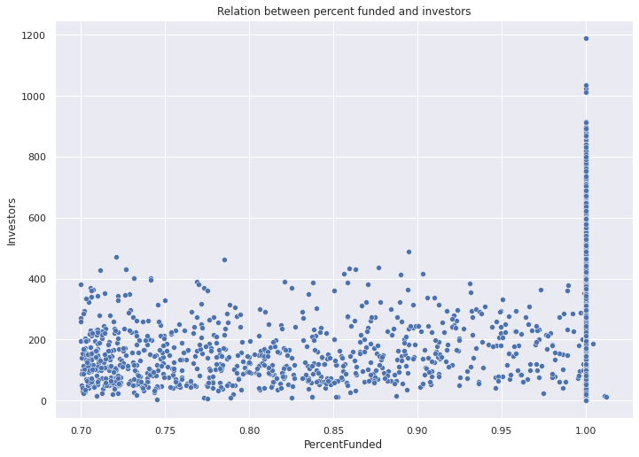

```python
# Bivariate relation by plotting 2 features of loans_df dataset on x and y axes and set the title
sns.scatterplot(data=loans_df, x="PercentFunded", y="Investors").set(title='Relation between percent funded and investors')
```

## Bivariate Chart

### Finding: It's found that most of loaners don't have recommendations to investors

```
[Text(0.5, 1.0, 'Relation between Recommendations and investors')]
```

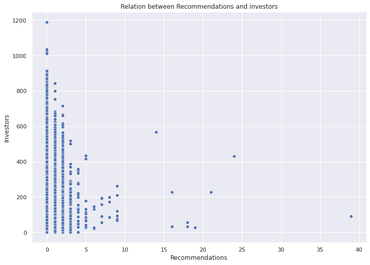

```python
# Bivariate relation by plotting 2 features of loans_df dataset on x and y axes and set the title
sns.scatterplot(data=loans_df, x="Recommendations", y="Investors").set(title='Relation between Recommendations and investors')
```

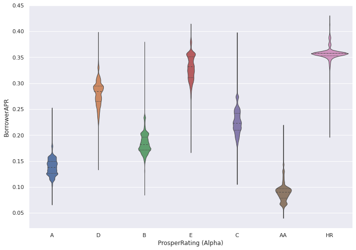

```python
sns.violinplot(data=loans_df, x="ProsperRating (Alpha)", y="BorrowerAPR",
               split=True, inner="quart", linewidth=1)
```

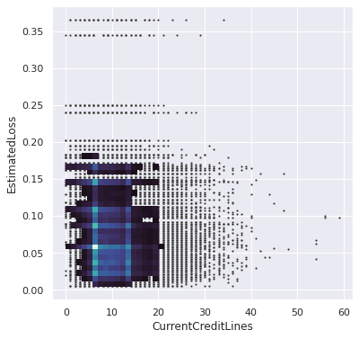

```python
f, ax = plt.subplots(figsize=(6, 6))
sns.scatterplot(x=loans_df.CurrentCreditLines, y=loans_df.EstimatedLoss, s=5, color=".15")
sns.histplot(x=loans_df.CurrentCreditLines, y=loans_df.EstimatedLoss, bins=50, pthresh=.1, cmap="mako")
```

# Findings